# Project_Part1_Stat_Modeling

### Step 14

```r
filtered$standardized_height <- {filtered$height-mean(filtered$height)}/sd(filtered$height)

filtered$standardized_aircraft <-{filtered$aircraft-mean(filtered$aircraft)}/sd(filtered$aircraft)

filtered$standardized_no_pasg <-{filtered$no_pasg-mean(filtered$no_pasg)}/sd(filtered$no_pasg)

filtered$standardized_no_pasg <-{filtered$no_pasg-mean(filtered$no_pasg)}/sd(filtered$no_pasg)

filtered$standardized_speed_ground<-{filtered$speed_ground-mean(filtered$speed_ground)}/sd(filtered$speed_ground)

filtered$standardized_speed_air<-{filtered$speed_air-mean(filtered$speed_air)}/sd(filtered$speed_air)

filtered$standardized_pitch <- {filtered$pitch-mean(filtered$pitch)}/sd(filtered$pitch)

lm(distance~standardized_pitch,data=filtered)
```

```
##
## Call:
## lm(formula = distance ~ standardized_pitch, data = filtered)
##
## Coefficients:
##        (Intercept)  standardized_pitch
##            1521.89               78.03
```

```r
lm(distance~standardized_speed_ground,data=filtered)
```

```
##
## Call:
## lm(formula = distance ~ standardized_speed_ground, data = filtered)
##
## Coefficients:
##               (Intercept)  standardized_speed_ground
##                    1521.9                      776.1
```

```r
lm(distance~standardized_no_pasg,data=filtered)
```

```
##
## Call:
## lm(formula = distance ~ standardized_no_pasg, data = filtered)
##
## Coefficients:
##          (Intercept)  standardized_no_pasg
##              1521.89                -16.14
```

```r
lm(distance~standardized_no_pasg,data=filtered)
```

```
##
## Call:
## lm(formula = distance ~ standardized_no_pasg, data = filtered)
##
## Coefficients:
##          (Intercept)  standardized_no_pasg
##              1521.89                -16.14
```

```r
lm(distance~standardized_aircraft,data=filtered)
```

```
##
## Call:
## lm(formula = distance ~ standardized_aircraft, data = filtered)
##
## Coefficients:
##           (Intercept)  standardized_aircraft
##                1521.9                  212.6
```

```r
lm(distance~standardized_height,data=filtered)
```

```
##
## Call:
## lm(formula = distance ~ standardized_height, data = filtered)
##
## Coefficients:
##         (Intercept)  standardized_height
##             1521.89                89.17
```

```r
table3 <- matrix(c('Speed_Ground','776.1','Positive','Aircraft','212.6','Positive',
                   'Height','89.17','Positive','Pitch','78.03','Positive',
                   'No_pasg','-16.14','Negative'),ncol = 3,byrow = TRUE)
colnames(table3) <- c('Name','Regression coefficient Size','Direction')
table3
```

```
##      Name           Regression coefficient Size Direction
## [1,] "Speed_Ground" "776.1"                     "Positive"
## [2,] "Aircraft"     "212.6"                     "Positive"
## [3,] "Height"       "89.17"                     "Positive"
## [4,] "Pitch"        "78.03"                     "Positive"
## [5,] "No_pasg"      "-16.14"                    "Negative"
```

### Step 15

```r
table1
```

[output not shown]

```r
table2
```

[output not shown]

```r
table3
```

```
##      Name           Regression coefficient Size Direction
## [1,] "Speed_Ground" "776.1"                     "Positive"
## [2,] "Aircraft"     "212.6"                     "Positive"
## [3,] "Height"       "89.17"                     "Positive"
## [4,] "Pitch"        "78.03"                     "Positive"
## [5,] "No_pasg"      "-16.14"                    "Negative"
```

The results are consistent as ground speed is the most important factor in all 3, but air speed is also very important. Aircraft seems to have some correlation.

- ground speed
- air speed
- aircraft

## Check collinearity

### Step 16

```r
collinearity1<- lm(distance~speed_ground, data = filtered)
collinearity2<- lm(distance~speed_air,data = filtered)
collinearity3<- lm(distance~speed_ground+speed_air,data=filtered)
collinearity1
```

```
##
## Call:
## lm(formula = distance ~ speed_ground, data = filtered)
##
## Coefficients:
##  (Intercept)  speed_ground
##     -1772.99         41.43
```

```r
collinearity2
```

```
##
## Call:
## lm(formula = distance ~ speed_air, data = filtered)
##
## Coefficients:
## (Intercept)    speed_air
##    -5455.71        79.53
```

```r
collinearity3
```

```
##
## Call:
## lm(formula = distance ~ speed_ground + speed_air, data = filtered)
##
## Coefficients:
##  (Intercept)  speed_ground     speed_air
##     -5462.28        -14.37         93.96
```

In model 3 air speed is added to ground speed and in this model ground speed decreases as air speed continues to increase. As ground speed is a more important factor in terms of correlation size, p-value, and regression coefficient size, I would keep this.

## Variable selection

### Step 17

```r
ranking_model1 <- lm(distance~speed_ground,data=filtered)
ranking_model2<- lm(distance~speed_ground+aircraft,data=filtered)
ranking_model3 <- lm(distance~speed_ground+aircraft+height,data = filtered)
ranking_model4 <- lm(distance~speed_ground+aircraft+height+pitch,data = filtered)
ranking_model5 <- lm(distance~speed_ground+aircraft+height+pitch+duration,data = filtered)
ranking_model6 <- lm(distance~speed_ground+aircraft+height+pitch+duration+no_pasg,data = filtered)

r.squared.1<- summary(ranking_model1)$r.squared; print(r.squared.1)
```

```
## [1] 0.7504239
```

```r
r.squared.2<- summary(ranking_model2)$r.squared; print(r.squared.2)
```

```
## [1] 0.8251847
```

```r
r.squared.3<- summary(ranking_model3)$r.squared; print(r.squared.3)
```

```
## [1] 0.8489497
```

```r
r.squared.4<- summary(ranking_model4)$r.squared; print(r.squared.4)
```

```
## [1] 0.8494237
```

```r
r.squared.5<- summary(ranking_model5)$r.squared; print(r.squared.5)
```

```
## [1] 0.8504184
```

```r
r.squared.6<- summary(ranking_model6)$r.squared; print(r.squared.6)
```

```
## [1] 0.8506023
```

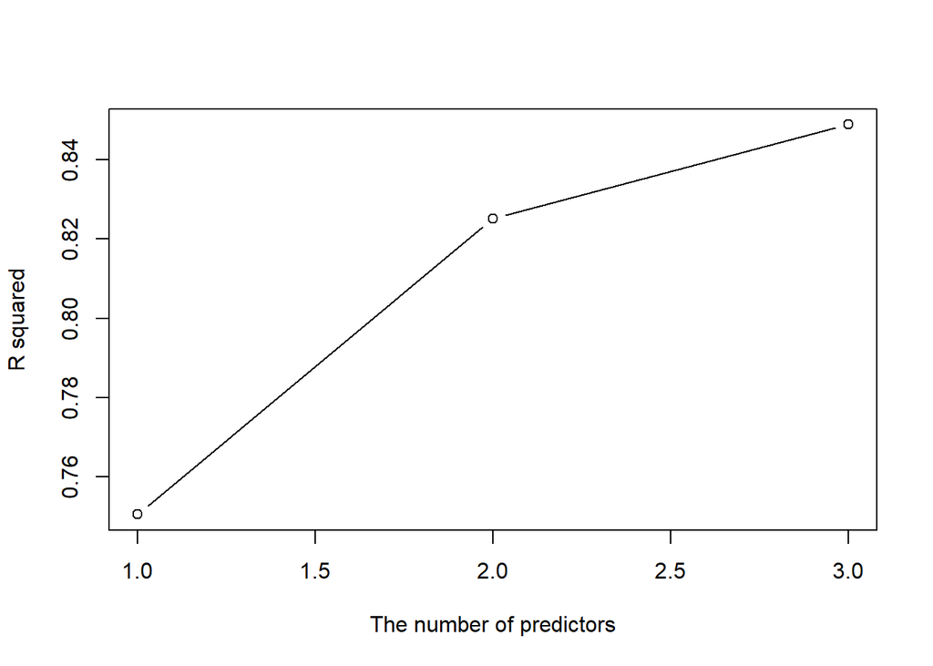

```r
plot(c(1,2,3),c(r.squared.1,r.squared.2,r.squared.3),type="b",ylab="R squared",xlab="The number of predictors")
```

As the number of predictors increases, so does the R squared value.

### Step 18

```r
adj.r.squared.1<-summary(ranking_model1)$adj.r.squared; print(adj.r.squared.1)
```

```
## [1] 0.7501232
```

```r
adj.r.squared.2<-summary(ranking_model2)$adj.r.squared; print(adj.r.squared.2)
```

```
## [1] 0.8247629
```

```r
adj.r.squared.3<-summary(ranking_model3)$adj.r.squared; print(adj.r.squared.3)
```

```
## [1] 0.8484024
```

```r
adj.r.squared.4<-summary(ranking_model4)$adj.r.squared; print(adj.r.squared.4)
```

```
## [1] 0.8486954
```

```r
adj.r.squared.5<-summary(ranking_model5)$adj.r.squared; print(adj.r.squared.5)
```

```
## [1] 0.8494534
```

```r
adj.r.squared.6<-summary(ranking_model6)$adj.r.squared; print(adj.r.squared.6)
```

```
## [1] 0.8494442
```

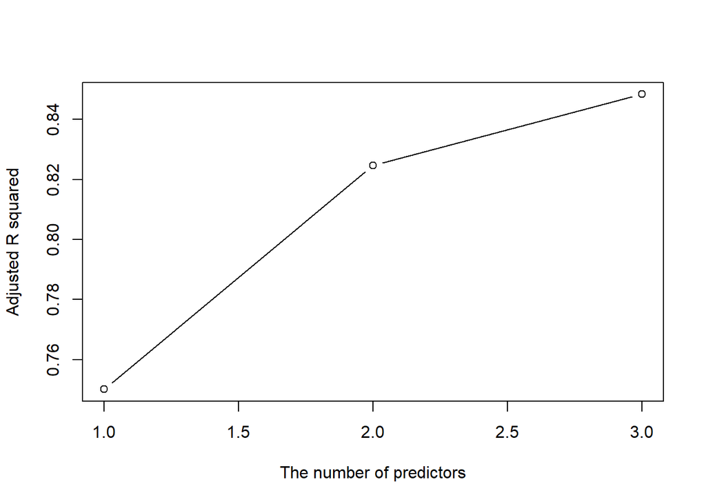

```r
plot(c(1,2,3),c(adj.r.squared.1,adj.r.squared.2,adj.r.squared.3),type="b",ylab="Adjusted R squared",xlab="The number of predictors")
```

### Step 19

```r
AIC(ranking_model1)
```

```
## [1] 12523
```

```r
AIC(ranking_model2)
```

```
## [1] 12228.78
```

```r
AIC(ranking_model3)
```

```
## [1] 12109.21
```

```r
AIC(ranking_model4)
```

```
## [1] 12108.6
```

```r
AIC(ranking_model5)
```

```
## [1] 11378.84
```

```r
AIC(ranking_model6)
```

```
## [1] 11379.88
```

### Step 21

```r
stepAIC(ranking_model1)
```

```
## Start:  AIC=10159.89
## distance ~ speed_ground
##
##                Df Sum of Sq       RSS   AIC
## <none>                      166487253 10160
## - speed_ground  1 500592905 667080159 11313
```

```
##
## Call:
## lm(formula = distance ~ speed_ground, data = filtered)
##
## Coefficients:
##  (Intercept)  speed_ground
##     -1772.99         41.43
```

```r
stepAIC(ranking_model2)
```

```
## Start:  AIC=9865.67
## distance ~ speed_ground + aircraft
##
##                Df Sum of Sq       RSS     AIC
## <none>                      116615838  9865.7
## - aircraft      1  49871415 166487253 10159.9
## - speed_ground  1 512921039 629536877 11266.5
```

```
##
## Call:
## lm(formula = distance ~ speed_ground + aircraft, data = filtered)
##
## Coefficients:
##  (Intercept)  speed_ground      aircraft
##     -2536.45         41.98        491.20
```

```r
stepAIC(ranking_model3)
```

```
## Start:  AIC=9746.1
## distance ~ speed_ground + aircraft + height
##
##                Df Sum of Sq       RSS     AIC
## <none>                      100762647  9746.1
## - height        1  15853192 116615838  9865.7
## - aircraft      1  50821351 151583998 10083.9
## - speed_ground  1 521695198 622457845 11259.1
```

```
##
## Call:
## lm(formula = distance ~ speed_ground + aircraft + height, data = filtered)
##
## Coefficients:
##  (Intercept)  speed_ground      aircraft        height
##     -3008.42         42.40        495.92         14.15
```

```r
stepAIC(ranking_model4)
```

```
## Start:  AIC=9745.48
## distance ~ speed_ground + aircraft + height + pitch
##
##                Df Sum of Sq       RSS     AIC
## <none>                      100446449  9745.5
## - pitch         1    316198 100762647  9746.1
## - height        1  15711945 116158394  9864.4
## - aircraft      1  41870629 142317078 10033.4
## - speed_ground  1 522011344 622457793 11261.1
```

```
##
## Call:
## lm(formula = distance ~ speed_ground + aircraft + height + pitch,
##     data = filtered)
##
## Coefficients:
##  (Intercept)  speed_ground      aircraft        height         pitch
##     -3145.87         42.43        481.15         14.09         39.66
```